# Task: Polish a Previous Visualization

# 28.3.1 Exercises

**1. Use geom_text() with infinite positions to place text at the four corners of the plot.**

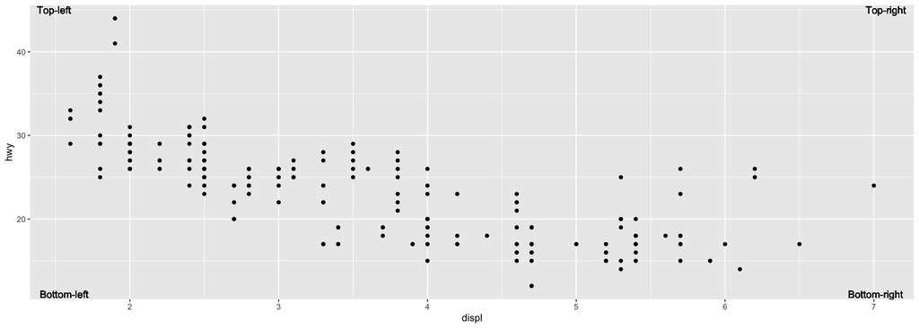

```r
library(ggplot2)

ggplot(mpg, aes(x = displ, y = hwy)) +
  geom_point() +
  geom_text(aes(x = -Inf, y = Inf, label = "Top-left"), hjust = -0.2, vjust = 1.2) +
  geom_text(aes(x = Inf, y = Inf, label = "Top-right"), hjust = 1.2, vjust = 1.2) +
  geom_text(aes(x = -Inf, y = -Inf, label = "Bottom-left"), hjust = -0.2, vjust = -0.2) +
  geom_text(aes(x = Inf, y = -Inf, label = "Bottom-right"), hjust = 1.2, vjust = -0.2)
```

```r
  #geom_dl(aes(label = Species), method = "smart.grid") +
```

**2. Read the documentation for annotate(). How can you use it to add a text label to a plot without having to create a tibble?**

The annotate() function allows you to directly add annotations without needing to create a separate data frame or tibble. It just kind of let’s you.

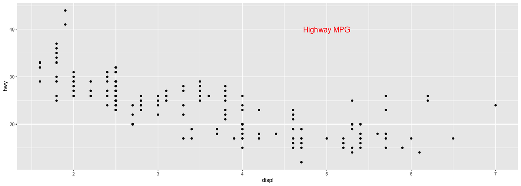

```r
ggplot(mpg, aes(x = displ, y = hwy)) +
  geom_point() +
  annotate("text", x= 5, y = 40, label = "Highway MPG", size = 5, colour = "red")
```

**3. How do labels with geom_text() interact with faceting? How can you add a label to a single facet? How can you put a different label in each facet?**

Labels with geom_text() work with faceting by being applied to all facets. If you want to add different labels to each facet, you’ll need to include the label in the data.

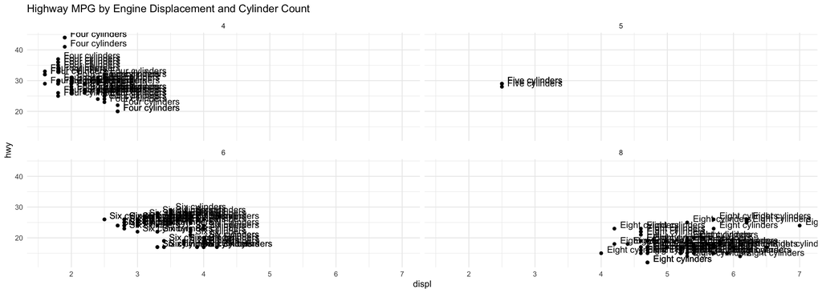

```r
facet_data <- mpg
facet_data$label <- ifelse(facet_data$cyl == 4, "Four cylinders",
                    ifelse(facet_data$cyl == 5, "Five cylinders",
                    ifelse(facet_data$cyl == 6, "Six cylinders",
                    ifelse(facet_data$cyl == 8, "Eight cylinders", NA))))
ggplot(facet_data, aes(x = displ, y = hwy)) +
  geom_point() +
  geom_text(aes(label = label), na.rm = TRUE, hjust = -0.1, vjust = -0.1) +
  facet_wrap(~cyl) +
  labs(title = "Highway MPG by Engine Displacement and Cylinder Count") +
  theme_minimal()
```

**4. What arguments to geom_label() control the appearance of the background box?**

Some arguments that control the appearance of the background box in geom_label() are:

- label.padding: Padding around the label, a unit object.
- label.size: Size of the label border.
- label.r: Corner radius for rounded corners of the label.

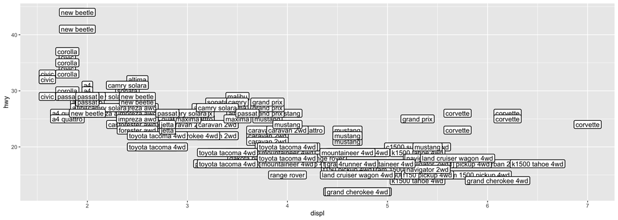

```r
ggplot(mpg, aes(x = displ, y = hwy)) + geom_point() +
  geom_label(aes(label = model),
    label.padding = unit(0.2, "lines"),
    label.size = 0.5,
    label.r = unit(0.15, "lines"))
```

**5. What are the four arguments to arrow()? How do they work? Create a series of plots that demonstrate the most important options.**

Four arguments to arrow() are:

- angle: Angle of the arrowhead in degrees.
- length: Length of the arrowhead.
- ends: Which end the arrow should be drawn on. Options are “first”, “last”, or “both”.
- type: Type of arrowhead. Options are “open” or “closed”.

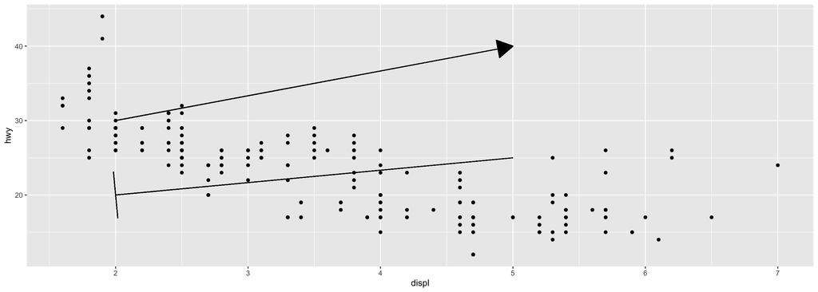

```r
ggplot(mpg, aes(x = displ, y = hwy)) +
  geom_point() +
  geom_segment(aes(x= 2, y = 30, xend = 5, yend = 40), arrow = arrow(angle = 30, length =unit(0.3, "inches"), ends = "last", type ="closed")) +
geom_segment(aes(x = 2, y = 20, xend = 5, yend = 25), arrow =arrow(angle = 90, length = unit(0.4, "inches"), ends = "first", type ="open"))
```